# Modèles Linéaires - Partie 1

4GMM - 2021-2022

*L’objectif de ce TP est d’illustrer les notions abordées dans le chapitre de régression linéaire.*

Les librairies `R` nécessaires pour ce TP sont les suivantes :

```r
library(ellipse)
library(leaps)
library(MASS)
library(corrplot)
library(glmnet)
library(plotly)
library(ggplot2)     # A mettre en commentaire si non utilisation des graphes ggplot
library(gridExtra)   # A mettre en commentaire si non utilisation des graphes ggplot
library(ggfortify)   # A mettre en commentaire si non utilisation des graphes ggplot
library(ggcorrplot)  # A mettre en commentaire si non utilisation des graphes ggplot
```

# 1 Introduction

La pollution de l’air constitue actuellement une des préoccupations majeures de santé publique. De nombreuses études épidémiologiques ont permis de mettre en évidence l’influence sur la santé de certains composés chimiques comme le dioxyde souffre (SO$_2$), le dioxyde d’azote (NO $_2$), l’ozone (O$_3$) ou des particules en suspension.

Des associations de surveillance de la qualité de l’air (Air Breizh en Bretagne depuis 1994) existent sur tout le territoire métropolitain et mesurent la concentration des polluants. Elles enregistrent également les conditions météorologiques comme la température, la nébulosité, le vent, les chutes de pluie en relation avec les services de Météo France…

L’une des missions de ces associations est de construire des modèles de prévision de la concentration en ozone du lendemain à partir des données disponibles du jour : observations et prévisions de Météo France. Plus précisément, il s’agit d’anticiper l’occurrence ou non d’un dépassement légal du pic d’ozone ($180 \mu g/m^3$) le lendemain afin d’aider les services préfectoraux à prendre les décisions nécessaires de prévention : confinement des personnes à risque, limitation du trafic routier.

Plus modestement, l’objectif de cette étude est de mettre en évidence l’influence de certains paramètres sur la concentration d’ozone (en $\mu g/m^3$) et différentes variables observées ou leur prévision. Les 112 données étudiées ont été recueillies à Rennes durant l’été 2001.

Les 13 variables observées sont :

- `maxO3` : Maximum de concentration d’ozone observé sur la journée en $\mu$gr/m3
- `T9`, `T12`, `T15` : Température observée à 9, 12 et 15h
- `Ne9`, `Ne12`, `Ne15` : Nébulosité observée à 9, 12 et 15h
- `Vx9`, `Vx12`, `Vx15` : Composante E-O du vent à 9, 12 et 15h
- `maxO3v` : Teneur maximum en ozone observée la veille
- `vent` : orientation du vent à 12h
- `pluie` : occurrence ou non de précipitations

Les données sont disponibles sur la page moodle du cours. Pour les importer, vous pouvez utiliser la commande suivante :

```r
ozone = read.table("ozone.txt")
```

Afin de vous familiariser avec les données, faites dans un premier temps une analyse de statistique descriptive. Vous pouvez utiliser les fonctions `summary()`, `boxplot()`, `pairs()`, `barplot()`, `corrplot()`, ….

```r
# A COMPLETER - Faire des stats descriptives des données
summary(ozone)
```

```
     maxO3              T9             T12             T15             Ne9
 Min.   : 42.00   Min.   :11.30   Min.   :14.00   Min.   :14.90   Min.   :0.000
 1st Qu.: 70.75   1st Qu.:16.20   1st Qu.:18.60   1st Qu.:19.27   1st Qu.:3.000
 Median : 81.50   Median :17.80   Median :20.55   Median :22.05   Median :6.000
 Mean   : 90.30   Mean   :18.36   Mean   :21.53   Mean   :22.63   Mean   :4.929
 3rd Qu.:106.00   3rd Qu.:19.93   3rd Qu.:23.55   3rd Qu.:25.40   3rd Qu.:7.000
      Ne12            Ne15           Vx9               Vx12             Vx15
 Min.   :0.000   Min.   :0.00   Min.   :-7.8785   Min.   :-7.878   Min.   :-9.000
 1st Qu.:4.000   1st Qu.:3.00   1st Qu.:-3.2765   1st Qu.:-3.565   1st Qu.:-3.939
 Median :5.000   Median :5.00   Median :-0.8660   Median :-1.879   Median :-1.550
 Mean   :5.018   Mean   :4.83   Mean   :-1.2143   Mean   :-1.611   Mean   :-1.691
 3rd Qu.:7.000   3rd Qu.:7.00   3rd Qu.: 0.6946   3rd Qu.: 0.000   3rd Qu.: 0.000
     maxO3v           vent              pluie
 Min.   : 42.00   Length:112         Length:112
 1st Qu.: 71.00   Class :character   Class :character
 Median : 82.50   Mode  :character   Mode  :character
 Mean   : 90.57
 3rd Qu.:106.00
 [ reached getOption("max.print") -- omitted 1 row ]
```

```r
head(ozone)
```

|  | maxO3 | T9 | T12 | T15 | Ne9 | Ne12 | Ne15 | Vx9 | Vx12 | Vx15 | maxO3v | vent | pluie |
| --- | --- | --- | --- | --- | --- | --- | --- | --- | --- | --- | --- | --- | --- |
| 20010601 | 87 | 15.6 | 18.5 | 18.4 | 4 | 4 | 8 | 0.6946 | -1.7101 | -0.6946 | 84 | Nord | Sec |
| 20010602 | 82 | 17.0 | 18.4 | 17.7 | 5 | 5 | 7 | -4.3301 | -4.0000 | -3.0000 | 87 | Nord | Sec |
| 20010603 | 92 | 15.3 | 17.6 | 19.5 | 2 | 5 | 4 | 2.9544 | 1.8794 | 0.5209 | 82 | Est | Sec |
| 20010604 | 114 | 16.2 | 19.7 | 22.5 | 1 | 1 | 0 | 0.9848 | 0.3473 | -0.1736 | 92 | Nord | Sec |
| 20010605 | 94 | 17.4 | 20.5 | 20.4 | 8 | 8 | 7 | -0.5000 | -2.9544 | -4.3301 | 114 | Ouest | Sec |
| 20010606 | 80 | 17.7 | 19.8 | 18.3 | 6 | 6 | 7 | -5.6382 | -5.0000 | -6.0000 | 94 | Ouest | Pluie |

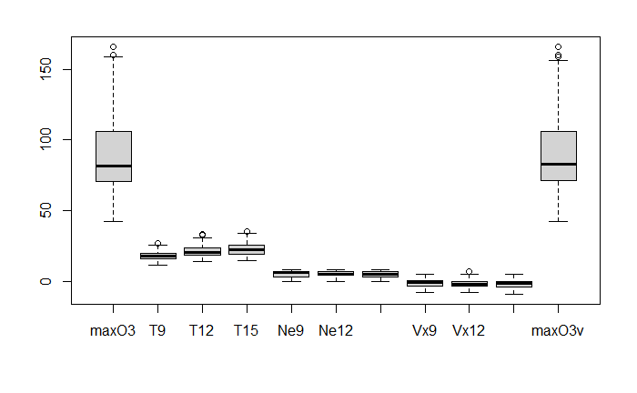

```r
boxplot(ozone[1:11])
```

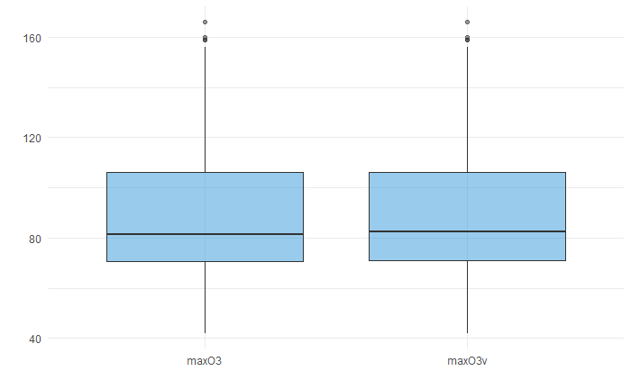

```r
df = stack(ozone[,c(1,11)])
ggplot(df, aes(x=df[,2],y=df[,1])) +
    geom_boxplot(fill="#3498db",alpha=.5) + xlab('') + ylab('') + theme_minimal()
```

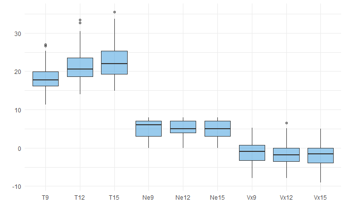

```r
df = stack(ozone[,2:10])
ggplot(df, aes(x=df[,2],y=df[,1])) +
    geom_boxplot(fill="#3498db",alpha=.5) + xlab('') + ylab('') + theme_minimal()
```

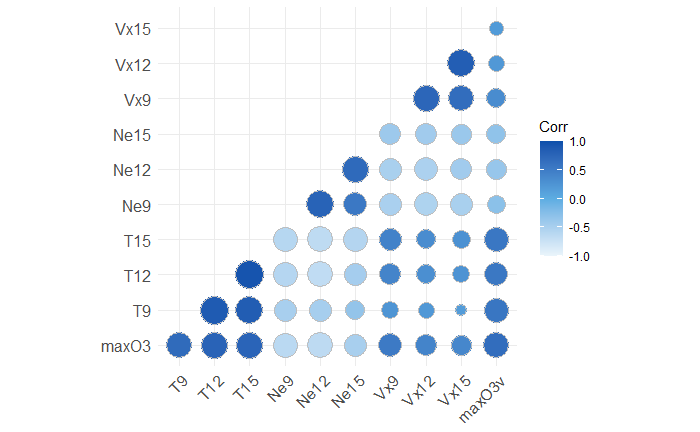

```r
corr <- cor(ozone[,1:11])

ggcorrplot(corr, method="circle",type="lower", ggtheme = ggplot2::theme_minimal,
           colors = c("#ebf5fb", "#5dade2", "#0d50ab" ))
```

# 2 Régression linéaire simple

Dans cette section, nous souhaitons expliquer la concentration d’ozone maximale de la journée (`maxO3`) en fonction de la température à 12h (`T12`).

1. Représentez le nuage de points $(x_i,y_i)$ à l’aide de la fonction `plot` ou `geom_point` de *ggplot2*.

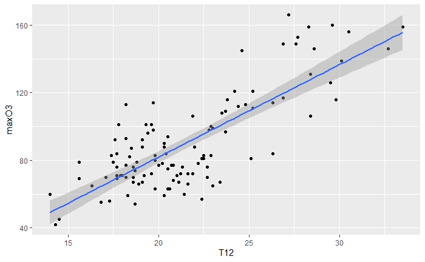

```r
# A COMPLETER
plot.simple = ggplot(ozone, aes(x = T12, y = maxO3))
plot.simple + geom_point() + geom_smooth(method = 'lm')
```

Pensez-vous que l’ajustement d’un modèle de régression linéaire $y_i = \theta_0+\theta_1 x_i +\varepsilon_i$ est justifié graphiquement ?

2. Effectuez la régression linéaire à l’aide de la fonction `lm` et exploitez les résultats.

```r
reg.simple = lm(maxO3 ~ T12, data = ozone)  # A COMPLETER
summary(reg.simple)
```

[output not shown]

```r
anova(reg.simple)
```

```
Analysis of Variance Table

Response: maxO3
           Df Sum Sq Mean Sq F value    Pr(>F)
T12         1  54244   54244  175.76 < 2.2e-16 ***
Residuals 110  33948     309
---
Signif. codes:  0 ‘***’ 0.001 ‘**’ 0.01 ‘*’ 0.05 ‘.’ 0.1 ‘ ’ 1
```

Commentaire : anova effectue un test de nullite de parametre associe a la variable T12, qui donne une p-value de $2.2e-16$

Que contiennent les sorties suivantes :

```r
reg.simple$coefficients
reg.simple$residuals
```

*Réponse* : Coefficients: l’estimation des parametres (les $\theta$) Residuals: les résidus

3. A l’aide des commandes suivantes, tracez l’estimation de la droite de régression sur le nuage de points ainsi qu’un intervalle de confiance à $95\%$ de celle-ci :

```r
scatter_plot <- ggplot(ozone,aes(x=T12,y=maxO3))+ geom_point()

scatter_plot +
    geom_smooth(method=lm, se=TRUE)+
    theme_minimal()+
    xlab("T12")+  ylab("maxO3")
```

La droite permet de vérifier graphiquement l’ajustement des données au modèle de régression linéaire. Que remarquez-vous ? Comment interprétez-vous l’intervalle de confiance ?

4. A l’aide de la commande suivante, étudiez les résidus

```r
autoplot(reg.simple,which=c(1,2),label.size=2)
```

[output not shown]

On prendra soin de comprendre les différents graphiques obtenus.

*Commentaire* : QQ plot: les residus suivent une loi gaussienne

5. Testez la normalité des résidus (à l’aide d’un test non-paramétrique).

```r
# A COMPLETER
residus = reg.simple$residuals
library(nortest)
lillie.test(residus) # Test de Kolmogorov - Smirnov
```

```
    Lilliefors (Kolmogorov-Smirnov) normality test

data:  residus
D = 0.042898, p-value = 0.881
```

*Commentaire* : p value > 0.05, donc à 95% de confiance, on peut supposer que les résidus suivent une loi gaussienne

6. On s’intéresse maintenant à la qualité de prédiction du modèle. On va donc tracer un intervalle de confiance des prédictions à $95\%$ avec les commandes suivantes.

```r
tmp = predict(reg.simple, interval="prediction")

df = cbind(ozone, tmp)
ggplot(df, aes(T12, maxO3))+
    geom_point() +
    geom_line(aes(y=lwr), color = "red", linetype = "dashed")+
    geom_line(aes(y=upr), color = "red", linetype = "dashed")+
    geom_smooth(method=lm, se=TRUE)+
    xlab("T12")+ ylab("maxO3")
```

```r
print(tmp)
```

```
               fit       lwr       upr
20010601  73.75103  38.69388 108.80819
20010602  73.20417  38.14115 108.26718
20010603  68.82922  33.71247 103.94597
20010604  80.31346  45.31186 115.31505
20010605  84.68840  49.70861 119.66820
20010606  80.86032  45.86212 115.85853
20010607  57.89185  22.58809  93.19561
20010610  68.28235  33.15804 103.40666
20010611  79.76659  44.76141 114.77177
20010612  92.34456  57.37351 127.31562
20010613  78.12598  43.10891 113.14305
20010614  83.59467  48.61056 118.57877
20010615  79.76659  44.76141 114.77177
20010616  72.11043  37.03512 107.18574
20010617  67.73548  32.60341 102.86755
20010618  77.03225  42.00629 112.05820
20010620 107.11001  72.05016 142.16986
20010621  95.07891  60.10189 130.05592
20010622 104.92254  69.88460 139.96048
20010623 128.98475  93.54022 164.42928
20010624 110.39122  75.29282 145.48963
20010625 151.40636 115.26349 187.54922
20010626 101.09446  66.08755 136.10137
20010627  97.81325  62.82551 132.80099
20010628  95.07891  60.10189 130.05592
 [ reached getOption("max.print") -- omitted 87 rows ]
```

*Commentaire* : Les nouvelles valeurs prédites sont compris dans l’intervalle de prédiction (à 95%)

6. On va maintenant s’intéresser à la construction d’intervalles de confiance pour $\theta_0$ et $\theta_1$ à $95\%$.  
   A l’aide de la fonction `confint()`, construisez un intervalle de confiance pour chaque paramètre séparément.

```r
IC = confint(reg.simple) # A COMPLETER
IC
```

[output not shown]

Pour tenir compte de la dépendance entre $\theta_0$ et $\theta_1$, on peut aussi construire une région de confiance pour le vecteur $\theta=(\theta_0,\theta_1)'$ grâce aux commandes suivantes. Comparez les résultats.

```r
df= as.data.frame(
  rbind(coefficients(reg.simple),ellipse(reg.simple,level=0.95)))
colnames(df) = c("intp", "slope")

ggplot(data=df[-1,],aes(x=intp, y=slope))+
  geom_path()+
  annotate("rect",xmin=IC[1,1],xmax=IC[1,2],
  ymin=IC[2,1],ymax=IC[2,2],fill="blue",alpha=0.1)+
  geom_point(data=df[1,], aes(x=intp, y=slope), pch=3)+
  theme_minimal()
```

[output not shown]

*Commentaire* : L’elippse signifie la region de confiance en supposant que les parametres sont dependants!!!

# 3 Régression linéaire multiple

Dans cette partie, nous souhaitons analyser la relation entre le maximum journalier de la concentration d’ozone `maxO3` et :

- la température à différentes heures de la journée (`T9`, `T12`, `T15`),
- la nébulosité à différentes heures de la journée (`Ne9`, `Ne12`, `Ne15`),
- la projection du vent sur l’axe Est-Ouest à différentes heures de la journée (`Vx9`, `Vx12`, `Vx15`),
- la concentration maximale d’ozone de la veille (`maxO3v`).

On va donc utiliser le sous-jeu de données suivant

```r
ozone1 = ozone[,1:11]
```

et mettre en place un modèle de régression linéaire multiple.

1. Faites une analyse descriptive de ce jeu de données.

```r
# A COMPLETER
summary(ozone1)
```

```
     maxO3              T9             T12             T15             Ne9
 Min.   : 42.00   Min.   :11.30   Min.   :14.00   Min.   :14.90   Min.   :0.000
 1st Qu.: 70.75   1st Qu.:16.20   1st Qu.:18.60   1st Qu.:19.27   1st Qu.:3.000
 Median : 81.50   Median :17.80   Median :20.55   Median :22.05   Median :6.000
 Mean   : 90.30   Mean   :18.36   Mean   :21.53   Mean   :22.63   Mean   :4.929
 3rd Qu.:106.00   3rd Qu.:19.93   3rd Qu.:23.55   3rd Qu.:25.40   3rd Qu.:7.000
 Max.   :166.00   Max.   :27.00   Max.   :33.50   Max.   :35.50   Max.   :8.000
      Ne12            Ne15           Vx9               Vx12             Vx15
 Min.   :0.000   Min.   :0.00   Min.   :-7.8785   Min.   :-7.878   Min.   :-9.000
 1st Qu.:4.000   1st Qu.:3.00   1st Qu.:-3.2765   1st Qu.:-3.565   1st Qu.:-3.939
 Median :5.000   Median :5.00   Median :-0.8660   Median :-1.879   Median :-1.550
 Mean   :5.018   Mean   :4.83   Mean   :-1.2143   Mean   :-1.611   Mean   :-1.691
 3rd Qu.:7.000   3rd Qu.:7.00   3rd Qu.: 0.6946   3rd Qu.: 0.000   3rd Qu.: 0.000
 Max.   :8.000   Max.   :8.00   Max.   : 5.1962   Max.   : 6.578   Max.   : 5.000
     maxO3v
 Min.   : 42.00
 1st Qu.: 71.00
 Median : 82.50
 Mean   : 90.57
 3rd Qu.:106.00
 Max.   :166.00
```

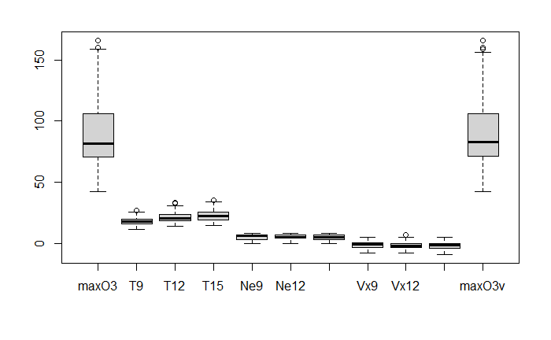

```r
boxplot(ozone1)
```

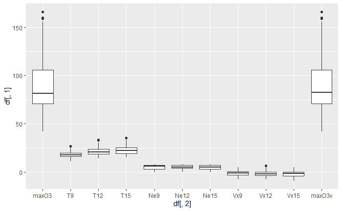

```r
df = stack(ozone1)
ggplot(df, aes(x = df[,2], y = df[,1])) + geom_boxplot()
```

2. Rappelez l’écriture mathématique du modèle de régression linéaire multiple.

$$Y_i = \theta_0 + \theta_1 x_{(i)}^1 + ... + \theta_{10} x_{(i)}^{10} + \epsilon_i$$

3. Ajustez un modèle de régression linéaire multiple à l’aide de la commande `lm()` et commentez les résultats.

```r
reg.mult = lm(maxO3 ~ ., data = ozone1) # A COMPLETER
summary(reg.mult)
```

[output not shown]

*Commentaire* : D’après les p values de test nullité, les thetas associés à maxO3v et Ne9 sont non null

4. Etudiez les résidus

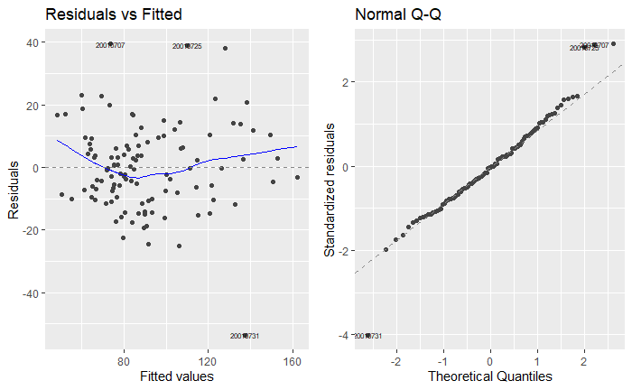

```r
# COMPLETER
autoplot(reg.mult, which = c(1,2), label.size = 2)
```

```r
lillie.test(reg.mult$residuals)
```

```
    Lilliefors (Kolmogorov-Smirnov) normality test

data:  reg.mult$residuals
D = 0.053322, p-value = 0.6056
```

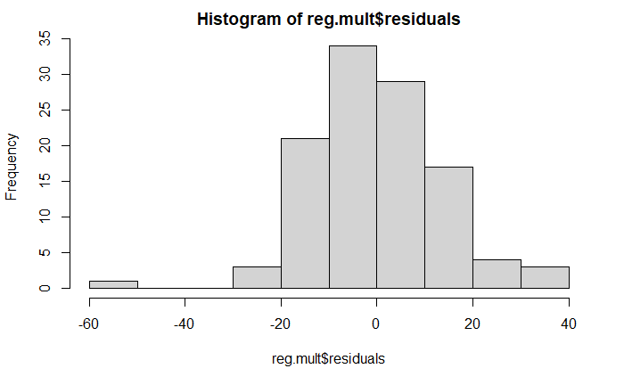

```r
hist(reg.mult$residuals)
```

*Commentaire* : Les résidus suivent une loi gaussienne

# 4 Sélection de variables

## 4.1 Introduction

De façon schématique, la pratique de la modélisation statistique vise trois objectifs éventuellement complémentaires :

- **Descriptif** : rechercher de façon exploratoire les liaisons entre $Y$ et d’autres variables, *potentiellement explicatives*, qui peuvent être nombreuses. Ces variables peuvent être nombreuses ; aussi, en terme de modélisation, il peut être pertinant de chercher l’ensemble de variable minimal (ou en tout cas de taille réduite) à même d’expliquer $Y$.
- **Explicatif** : Cet objectif est sous-tendu par une connaissance *a priori* du domaine concerné et dont des résultats théoriques peuvent vouloir être confirmés, infirmés ou précisés par l’estimation des paramètres. Dans ce cas, les résultats inférentiels permettent de construire le bon test conduisant à la prise de décision recherchée.
- **Prédictif** : On met l’accent sur la qualité des prévisions. C’est la situation rencontrée en apprentissage. Ceci conduit à rechercher des modèles parcimonieux c’est-à-dire avec un nombre volontairement restreint de variables explicatives pour réduire la variance. Un bon modèle n’est donc plus celui qui explique le mieux les données au sens d’un $R^2$ maximum mais celui conduisant aux prévisions les plus fiables.

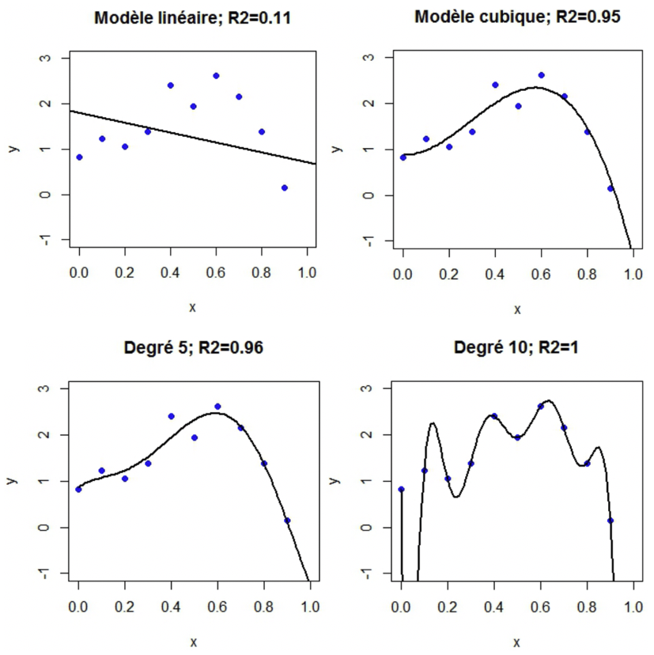

*Exemple* (Régression polynomiale) : L’ajustement du modèle mesuré par le $R^2$ croît avec le nombre de paramètres et atteint la valeur 1 lorque le polynôme interpole les observations.

Le $R^2$ ne peut-être un bon critère de sélection de modèles ; il ne peut servir qu’à comparer des modèles de même dimension car sinon conduit à sélectionner le modèle le plus complexe, c’est-à-dire celui correspond au plus grand espace de projection, et conduit donc au sur-ajustement.

## 4.2 Critères de sélection de variables

Dans le `summary(reg.mult)`, un test est fait sur chaque coefficient. Il revient à tester que la variable n’apporte pas d’information supplémentaire sachant que toutes les autres variables sont dans le modèle. Plus généralement, on souhaierait déterminer les variables significatives dans notre modèle. Pour cela on va recourir à une procédure de choix de modèle (cf § 8.6 du poly). Ces procédures reposent sur l’utilisation de critères de sélection.

Contrairement au $R^2$, ces critères sont basés sur une qualité de prévision. On peut par exemple recourir au critére $C_p$ de Mallows, au critère d’information d’Akaïke ($AIC$), au critère bayésien de Sawa ($BIC$).

En pratique, on utilise la fonction `regsubsets()` de la librairie *leaps* et la fonction `stepAIC()` de la librairie *MASS*.

1. Commentez les résultats obtenus avec les différents critères, vous pourrez vous aider des commandes suivantes :

```r
select=regsubsets(maxO3 ~ ., data = ozone1, nvmax = 10, method = 'backward',) # A COMPLETER
res <- summary(select)
res

str('\ ')
str(data.frame(AdjR2 = which.max(res$adjr2),
  Cp = which.min(res$cp),
  BIC = which.min(res$bic) ))

plot(select,scale="Cp")
plot(select,scale="adjr2")
plot(select,scale="bic")
```

[output not shown]

En particulier, avec le critère $BIC$, combien de variables sélectionne-t-on et quelles sont elles ?

*Réponse* : 4 variables : T12, Ne9, Vx9, maxO3v

2. Retrouvez le même résultat avec le critère $AIC$

```r
stepAIC(reg.mult) # A COMPLETER
```

[output not shown]

3. Testez le sous-modèle avec les variables retenues par $BIC$ contre le modèle complet.

```r
reg.bic=lm(maxO3 ~ T12 + Ne9 + Vx9 + maxO3v, data = ozone1) # A COMPLETER
summary(reg.bic)

anova(reg.bic,reg.mult)
```

[output not shown]

*Commentaire* : Res.Df : Residual Degrees of freedom = nb. observations - nb. variables explicatives RSS = Residual Sum of Squares = $\sum (y_i - \hat{y_i})^2$ Df : difference des nombres des variables explicatives Sum of Sq: difference entre RSS des deux modeles F : Statistique de test de Fisher-Snedecor (p.27) Pr : p-value

```r
RSS1 = sum((ozone1$maxO3 - fitted(reg.bic))^2)
print(RSS1)
```

```
[1] 20970.24
```

```r
Y.hat.0 = fitted(reg.bic)
Y.hat = fitted(reg.mult)
k = length(ozone1)
k0 = 5
n = length(ozone1[,1])
Y = ozone1$maxO3
F = (norm(Y.hat - Y.hat.0, type = '2')^2/(k - k0)) / (norm(Y - Y.hat, type = '2')^2/(n - k))
print(F)
```

```
[1] 0.1155863
```